# flowAI report

SIgN_GM

## FCS file information

> Input file name: Specimen_001_BRUTTO_MS_016_RZ_HC_del_17-10-22  
> Number of events: 2143038

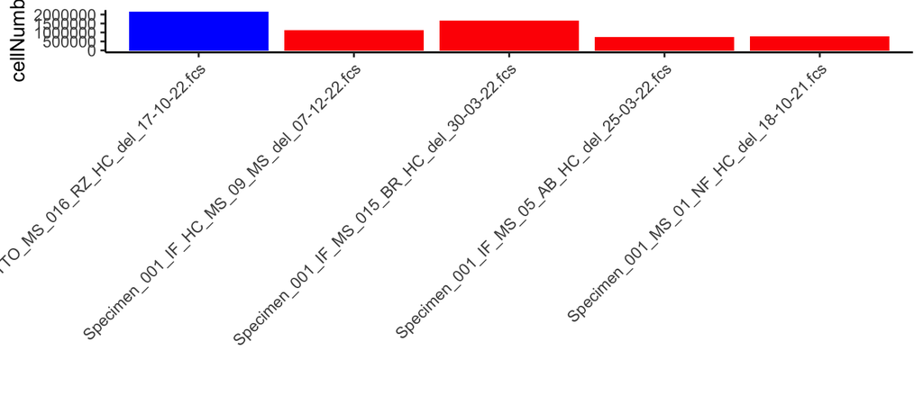

Comparison of the number of events stored in the FCS files of the entire dataset. In blue is highlighted the FCS file whose quality control analysis is described in this report.

## Quality control analysis

### Summary

> The anomalies were removed from: Flow Rate, Flow Signal and Flow Margin  
> Anomalies detected in total: **87.25** %  
> Number of high quality events: 273218

### Flow rate check

> **24** % anomalies detected in the flow rate check.

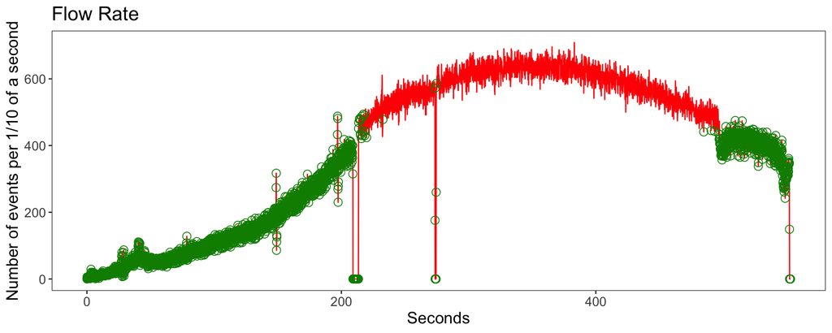

The plot reconstructs the flow rate with a resolution of 1/10 of a second. Anomalies in the flow rate are identified with an algorithm based on the generalied ESD outlier detection method. The anomalies are circled in green.

### Signals acquisition check

> **82.99** % anomalies detected in the signal aquisition check.

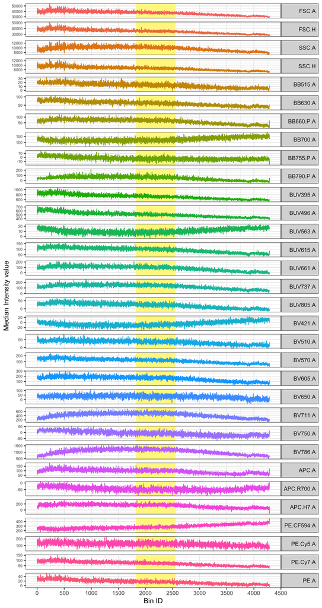

The more stable region selected consistent for all channels is highlighted in yellow. If the removal of outliers has been required before the execution of the changepoint analysis, the detected outliers are cicled in green.

The FCS file was divided in 4287 bins, hence each bin contains 500 event(s). The stable region is located between the bins 1827 and 2555.

##### More info on the changepoints detected

Changepoints detected in channels with shifts in signal acquisition:

```
              1    2    3
BB515.A    1106 2875
BB630.A     784 2650 3368
BB660.P.A  2877 3553
BB700.A    2977
BB755.P.A  1283
BB790.P.A  2953 3507
BUV395.A   1107 2875 3490
BUV496.A    716 2787 3404
BUV563.A    368 3288
BUV615.A   1359 2863 3509
BUV661.A   2883 3553
BUV737.A   3008 3535
BUV805.A   1827 2917
BV421.A    3044
BV510.A    2946
BV570.A    1360 2873 3362
BV605.A    2912 3449
BV650.A    3565
BV711.A     369 2865 3291
BV750.A    1215 2555
BV786.A     483 2875 3304
APC.A      2848
APC.R700.A  688
APC.H7.A   2893
PE.CF594.A 1788 2912 3568
PE.Cy5.A   2956
PE.Cy7.A   1106 2864 3465
PE.A        763 2719 3488
```

Channels excluded from the analysis: FSC.A, FSC.H, SSC.A, SSC.H.

### Dynamic range check

> **22.83** % anomalies detected in dynamic range check.

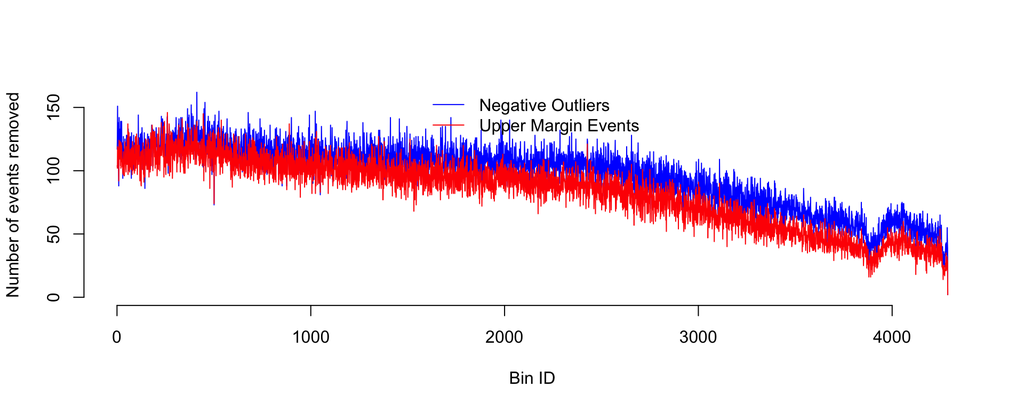

The plot shows where the anomalies occured the most. The x-axis scale is complementary to the one of the signal acquisition plot.

##### More info on the anomalies detected in the dynamic range check

For each channel analyzed, the table shows the number of events that did not pass the dynamic range check:

```
             lower_range upper_range
BB515.A            16568           6
BB630.A            30915          45
BB660.P.A           1750         114
BB700.A            17678          14
BB755.P.A          91450          14
BB790.P.A           5693      322064
BUV395.A             911         195
BUV496.A             796         206
BUV563.A          173804          42
BUV615.A           13288         112
BUV661.A            3700         358
BUV737.A            2483         124
BUV805.A           14078          96
BV421.A            40872          27
BV510.A            16354         137
BV570.A            15153          74
BV605.A            13784         202
BV650.A            44006         100
BV711.A            13073         487
BV750.A            72537          70
BV786.A             2301      347425
APC.A               8354         249
APC.R700.A        118627          32
APC.H7.A           80341          95
PE.CF594.A           686         157
PE.Cy5.A            4043        6015
PE.Cy7.A            1744          46
PE.A               13708          26
total_SUM         818697      678532
total_UNIQUE      413114      353961
```

Channels excluded from the analysis: FSC.A, FSC.H, SSC.A, SSC.H.

Warning! Some values were found to be out of range from the upper limit! Here is a summary table:

```
    Channel Max upper value n. of values out of range
      FSC.A          262144                     93262
      FSC.H          262144                      1538
      SSC.A          262144                      2638
    BB515.A          262144                         6
    BB630.A          262144                        45
  BB660.P.A          262144                       114
    BB700.A          262144                        14
  BB755.P.A          262144                        14
  BB790.P.A          262144                    322064
   BUV395.A          262144                       195
   BUV496.A          262144                       206
   BUV563.A          262144                        42
   BUV615.A          262144                       112
   BUV661.A          262144                       358
   BUV737.A          262144                       124
   BUV805.A          262144                        96
    BV421.A          262144                        27
    BV510.A          262144                       137
    BV570.A          262144                        74
    BV605.A          262144                       202
    BV650.A          262144                       100
    BV711.A          262144                       487
    BV750.A          262144                        70
    BV786.A          262144                    347425
      APC.A          262144                       249
 APC.R700.A          262144                        32
   APC.H7.A          262144                        95
 PE.CF594.A          262144                       157
   PE.Cy5.A          262144                      6015
   PE.Cy7.A          262144                        46
       PE.A          262144                        26
```